# Comparison of the irlba and RSpectra packages

I introduced Baglama and Reichel’s irlba algorithm to the R world in a talk at the useR! conference in Dortmund way back in 2008, and a stable version of the package has been on CRAN for more than five years. I guess I should have anticipated the day when something new and faster would come along, but I admit my surprise when it happened…

In an interview with Lila Azam Zanganeh printed in the Paris Review (2008), Umberto Eco said

> Since I became a novelist I have discovered that I am biased. Either I think a new novel is worse than mine and I don’t like it, or I suspect it is better than my novels and I don’t like it.

(Read the whole interview here: http://www.theparisreview.org/interviews/5856/the-art-of-fiction-no-197-umberto-eco .)

I experienced, briefly, just such an Umberto Eco moment after I became aware of the excellent RSpectra package by Yixuan Qiu (see https://github.com/yixuan and http://statr.me/) this summer (2016). Indeed, the RSpectra package was quite a bit *faster* (lower elapsed times) and apparently *more efficient* (less CPU time at least) than my venerable irlba package for computing truncated singular value decomposition. But curiosity prevailed as I tried to understand the performance differences and then address them in irlba. For technical reasons described below, I knew that irlba *should* be more efficient than the approach taken by RSpectra, at least for SVD-like problems.

# Important references

- The irlba package relies on: Augmented Implicitly Restarted Lanczos Bidiagonalization Methods, J. Baglama and L. Reichel, SIAM J. Sci. Comput. (2005). (http://www.math.uri.edu/~jbaglama/papers/paper14.pdf)
- RSpectra is based on algorithms from Lehoucq and Sorenson’s “ARPACK: Fortran subroutines for solving large scale eigenvalue problems.” (1994). (See also Lehoucq’s Ph. D. thesis: Lehoucq, R. B. “Analysis and Implementation of an Implicitly Restarted Arnoldi Iteration.” (1995). http://www.caam.rice.edu/tech_reports/1995/TR95-13.pdf.)

A truly vast literature cites the large body of ARPACK work. A smaller, but rapidly growing number of papers cite the IRLB methods.

# Upshot

After some work, the (new) irlba implementation is faster and more efficient than RSpectra for truncated singular value decompositions and PCA, precisely the problems for which irlba was designed.

RSpectra is a really impressive package and I encourage you to try it out and use it especially for eigenvalue problems. Although irlba can solve *some* specialized partial eigenvalue problems, RSpectra is overall better for that purpose because the algorithms it uses are designed for such problems. Conversely, although RSpectra *can* be used to solve truncated SVD and PCA problems, its algorithms aren’t really specialized for that purpose.

**[By the way, Jim Baglama informs me that the Mathworks now uses irlba in their ‘svds’ function (not to be confused with the ‘svds’ function in the RSpectra R package discussed in this note). See http://www.mathworks.com/help/matlab/ref/svds.html and http://meetings.siam.org/sess/dsp_talk.cfm?p=79628 .]**

**[Sorry, I can’t help but add that of course R has had this function available for many years and many users and other R packages rely on it. I guess it’s hard for proprietary software companies to keep up with the times–they have to spend so much effort on marketing after all.]**

# Why is the new irlba faster than the old one?

I’d like to say it was due to mathematical insight but, alas, the main reason is that I re-coded the core algorithm in C instead of R. I chose to implement the original method completely in R because it was so fast anyway (compared to available alternatives at the time), and I preferred to keep the code easier to read to promote understanding of the method.

Plus I find that R programs are usually quite fast so that resorting to lower-level languages like Fortran, C, or C++ should be done sparingly and only after it’s clear that a better R implementation is not easily attainable.

I made the interesting discovery that simply coding the R irlba function in C does not tell the whole story. It turns out that a large portion of the performance improvement comes from low-level invocation of BLAS level 2 operations (matrix times vector products), which are not available directly from R. At the moment, R’s default matrix multiplication routines always resort to level 3 BLAS even when one argument is a vector–leading to sub-optimal performance (see the matprod functions in R’s array.c source code). I’m investigating improving this in the base R language now. I hope that at some point, the pure R reference implementation might be almost as fast as the new lower-level C code!

**[Lothar Reichel reminded me that a block variation of the algorithm exists, see J. Baglama and L. Reichel Restarted block Lanczos bidiagonalization methods Numer. Algorithms, 43 (2006), pp. 251-272. The block version uses mostly level 3 BLAS and probably would have run much faster in plain old R than the original version I implemented. Perhaps a future implementation of the package will include the block version.]**

Note that I retained the original R reference implementation and it can be invoked with the `fastpath=FALSE` argument. I kept it around because a few edge cases still use that code path (custom matrix products for instance, and also complex-valued matrix problems because I haven’t got to that yet in the C code). But also I like having the reference implementation there for users to read, to easily debug and step through, and to help understand the algorithm better.

# Performance and efficiency comparison of irlba and RSpectra

Let me reiterate that RSpectra is a great package. It’s just that we know that the irlba algorithms should, at least theoretically, out-perform ARPACK-like methods for truncated SVD computation, where the phrase “out-perform” means compute a similar solution estimate with fewer floating point operations.

The following examples compare `irlba` and the `svds` function from RSpectra by absolute performance (elapsed run time) and one measure of efficiency (total resident memory use) for two generic problems. These aren’t exhaustive tests, but give you the feel for differences in the packages.

I ran the following examples on an old-ish but powerful computer with two Intel Xeon CPU E5-2650 processors (16 physical CPU cores) running at 2 GHz equipped with 128 GB of ECC DDR3 RAM running the 64-bit Ubuntu 14.04 operating system and R version 3.3.1. R was rigged to use the libopenblas implementation of the Goto BLAS, with the environment variable `OMP_NUM_THREADS=16` set to avoid over subscription of CPU floating point resources. I used the flexible dynamic shared BLAS library linkage approach outlined in https://cran.r-project.org/doc/manuals/R-admin.html#Shared-BLAS (really, the best way to link R to BLAS in my opinion). The test RSpectra package version was 0.12-0 (2016-06-12), and the tested irlba version was 2.1.0.

## Problem 1: Compute the largest 3 singular values and corresponding singular vectors for a dense 30,000 by 30,000 matrix

Large, square matrices are a typically good case for clever truncated SVD algorithms like `svds` and `irlba` just because they are so hard to compute otherwise. The input matrix itself consumes about 6.7 GiB (7.2 GB) RAM. That seems like a lot, but the test computer has plenty more (128 GB). The entries of the matrix are sampled from a standard normal distribution with R’s `rnorm` function, see the Appendix for details.

The core of the following comparison compares

```r
l = irlba(x, 3, tol=1e-5)
```

with

```r
s = svds(x, 3, tol=1e-5)
```

I set the tolerance uniformly across the methods, although I’m not really sure what tolerance means in the `svds` function (more on that in the next section below).

In order to carefully track real memory use while the algorithm runs, I take advantage of some Linux capabilities and use R’s parallel package to fork each experiment in a separate (child) R process, letting the master R process monitor the child’s progress and memory use until it finishes. Algorithm run times are self-reported by the child processes back to the master. See the Appendix section for full program listings that I used to compare performance and carefully track memory use.

The test program writes an output file named ‘dense.out’ that contains the total elapsed times for `irlba` and `svds` in the `l_dense` and `s_dense` variables, respectively, and the matrices `mem_l_dense` and `mem_s_dense` that track detailed memory usage by the R process running each algorithm in approximately 1/10 second intervals.

## Results

Elapsed wall-clock times for each method and problem are shown in the plots below. In the 30,000 × 30,000 dense matrix case, `irlba` was about 6 times faster than `svds`, but `irlba` was only about 4 times faster in the large sparse matrix case. I’ll point out that any benchmarking result of these methods will strongly depend on the hardware and BLAS library used, in this example it was OpenBLAS (http://www.openblas.net/).

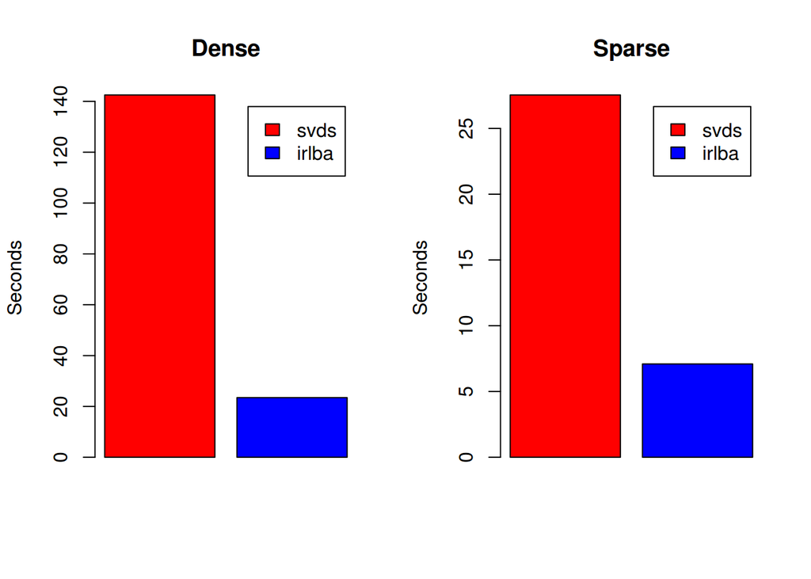

```r
load("sparse.out")
load("dense.out")
par(mfrow=c(1,2))
barplot(c(s_dense, l_dense), ylab="Seconds", col=c(2, 4), legend=c("svds", "irlba"), main="Dense")
barplot(c(s_sparse, l_sparse), ylab="Seconds", col=c(2, 4), legend=c("svds", "irlba"), main="Sparse")
```

Peak memory use during computation of the sparse case was similar for the two methods, with `svds` using slightly less memory than `irlba` (2.4 GiB versus 2.6 GiB, respectively). The next plot shows memory use in GiB over time for each method for the sparse problem. Despite similar peak use, memory use over time while each algorithm runs is interestingly different. (Note that Linux reports resident memory use in pages, which on our test system means 4096 bytes.) I used the following program to plot memory use:

```r
t = seq(1:nrow(mem_s_sparse)) / 10  # approx. time in seconds
plot(t, 4096 * mem_s_sparse[, 2] / 2 ^ 30, type='l', col=2, lwd=4, ylab="",
     ylim=c(0, 4096 * max(mem_s_sparse[, 2], mem_l_sparse[, 2]) / 2^30),
     xlab="time (seconds)", main="Sparse problem resident memory use (GiB)",
     cex=2, cex.axis=1.5, cex.lab=1.5, cex.main=1.8)
lines(t[1:nrow(mem_l_sparse)], 4096 * mem_l_sparse[,2] / 2 ^ 30, col=4, lwd=4)
grid()
legend("bottomright", legend=c("svds", "irlba"), fill=c(2, 4), bty="n", cex=2)
```

Unlike the sparse problem case, the dense problem exhibits significantly different memory use patterns. The `irlba` peak memory during computation of the dense 30,000 × 30,000 problem was about 6.8 GiB (just slightly more than the 6.7 GiB required to store the input matrix), but `svds` used much more–a peak of 53.8 GiB.

[figure not shown]

[figure not shown]

```r
t = seq(1:nrow(mem_s_dense)) / 10  # approx. time in seconds
plot(t, 4096 * mem_s_dense[, 2] / 2 ^ 30, type='l', col=2, lwd=4, ylab="",
     ylim=c(0, 4096 * max(mem_s_dense[, 2], mem_l_dense[, 2]) / 2^30),
     xlab="time (seconds)", main="Sparse problem resident memory use (GiB)",
     cex=2, cex.axis=1.5, cex.lab=1.5, cex.main=1.8)
lines(t[1:nrow(mem_l_dense)], 4096 * mem_l_dense[,2] / 2 ^ 30, col=4, lwd=4)
grid()
legend("bottomright", legend=c("svds", "irlba"), fill=c(2, 4), bty="n", cex=2)
```

# More thoughts on differences in RSpectra and irlba

What makes these algorithms different? The irlba approach directly estimates the decomposition $AV_k = U_kD_K$ for diagonal matrix of $k$ singular values $D_k$ and left and right singular basis matrices with orthonormal columns $U_k$ and $V_k$ for an input matrix $A$. Similarly to ARPACK-like methods, irlba uses an implicit restarting acceleration scheme to perform this estimation efficiently.

The `svds` function is based on the RSpectra ARPACK-like eigenvalue decomposition methods. It computes a few eigenvalues and eigenvectors of the matrix $A^T A$ (or $A A^T$, depending on the matrix size) to form the eigenvalue decomposition $A^T A V_k = V_k D_k ^2$, where $V_k$ is a matrix of right singular vectors for $A$, and $D_k ^ 2$ is the diagonal matrix of *squared* singular values of $A$. The `svds` function then computes $D_k$ by taking the square roots of the diagonal entries of the matrix $D_k ^ 2$ and then computes the left singular vectors as $U_k = A V_k D_k ^ {-1}$. A few things are worth noting here.

1. RSpectra is careful to work only implicitly with the matrix $A A^T$ or $A^T A$ without ever explicitly forming it. But still, `svds` solves an eigenvalue problem associated with one of those matrices. Note that the numerical condition number of $A A^T$ and $A^T A$ is potentially much worse than that of $A$. For well-conditioned matrices $A$ this might not be that big of a deal, but for ill-conditioned problems that can slow convergence of the method. This is one general reason why we expect irlba to need fewer flops.
2. `svds` computes eigenvalues that are the squares of the desired singular values, then takes their square roots, and then inverts those to compute either the left or right singular values depending on the size of the matrix. If some of the desired singular values are small or the differences between them are small, then the computed eigenvalues can underflow in floating point arithmetic and lose accuracy. That loss of accuracy carries through and can further accumulate in the singular vector solution step.

Here are a few pathological examples that illustrate these points. The examples explicitly construct matrices with known singular vectors and singular values, and then compute truncated singular value decompositions using R’s default `svd` function, `irlba`, and `svds`. The examples then compare the differences in the computed singular values and the 2-norm error in the computed singular vectors for each approach.

## Pathological example 1

The following example creates a numerically well-conditioned toy matrix `x` that has a few closely-spaced singular values. Although this example is unlikely to occur in practice, the results warrant caution.

```r
library(irlba, quietly=TRUE)
library(RSpectra)

set.seed(1)
N = 3
tol = 1e-15
d = c(1 + 1e-12, 1, 1 - 1e-12, 0.5, 0.4, 0.3)
m = length(d)
u = qr.Q(qr(matrix(rnorm(m ^ 2), m)))
v = qr.Q(qr(matrix(rnorm(m ^ 2), m)))
x = u %*% diag(d) %*% t(v)

s = svd(x)
z = svds(x, N, tol=tol)
l = irlba(x, N, tol=tol)
```

```
## Warning in irlba(x, N, tol = tol): You're computing a large percentage of
## total singular values, standard svd might work better!
```

```r
# Exact minus computed singular values for each method
print(rbind(svd=d[1:N] - s$d[1:N], irlba=d[1:N] - l$d, svds=d[1:N] - z$d))
```

```
##               [,1]          [,2]          [,3]
## svd   4.440892e-16 -2.220446e-16  2.220446e-16
## irlba 2.220446e-16  0.000000e+00  1.110223e-16
## svds  5.122569e-13 -4.714007e-13 -4.041212e-14
```

We see that in this example, each algorithm does a pretty OK job of estimating the top three singular values. We get a warning from irlba that we’re computing a large percentage of them. Ironically and despite the warning, `irlba`’s estimates are slightly more accurate than `svd` in this example (your results may vary depending on BLAS library in use).

The `bdiff` function below compares the squared 2-norm errors of singular vectors correcting for possible sign differences (singular vectors are only unique up to sign). Despite the relative accurate estimation of singular values, `svds` exhibits a near complete loss of accuracy and seriously mis-estimates the singular vectors (even though the matrix is well-conditioned).

```r
bdiff = function(x, y)
{
  s = sign(x[1,] / y[1,])
  apply(sweep(x, 2, s, `*`) - y, 2, crossprod)
}

# Exact minus computed singular vector 2-norm errors for each method, up to sign
print(rbind(svd_v = bdiff(v[,1:N], s$v[, 1:N]),
      svd_u   = bdiff(u[, 1:N], s$u[, 1:N]),
      irlba_v = bdiff(v[, 1:N], l$v),
      irlba_u = bdiff(u[, 1:N], l$u),
      svds_v  = bdiff(v[, 1:N], z$v),
      svds_u  = bdiff(u[, 1:N], z$u)))
```

```
##                 [,1]         [,2]         [,3]
## svd_v   3.141039e-08 3.344693e-08 2.576292e-09
## svd_u   3.141039e-08 3.344693e-08 2.576292e-09
## irlba_v 1.071655e-07 2.673764e-07 1.948729e-07
## irlba_u 1.071655e-07 2.673764e-07 1.948729e-07
## svds_v  6.025461e-01 6.164201e-01 2.537881e-02
## svds_u  6.025461e-01 3.383580e+00 2.537881e-02
```